# OpenData

Nicolas Stern

9 janvier 2019

# 1. Daten Laden

Laden Sie den Datensatz gemeindedaten.csv.

Dies setzt voraus, dass die Datenquelle (gemeindedaten.csv) im selben Verzeichnis ist, wie die *.Rmd Datei.

```r
gemeindedaten.raw <- read.table("gemeindedaten.csv",
                                header=TRUE,
                                sep = "," ,
                                na.strings = c("NA","*"),
                                fileEncoding = "UTF-8")
```

# 2. Daten prüfen

```r
head(gemeindedaten.raw)
```

```
##   bfsid           gmdename kantone grossregionen sprachregionen stadt_land
## 1     1    Aeugst am Albis      ZH        Zürich        deutsch      Agglo
## 2     2 Affoltern am Albis      ZH        Zürich        deutsch      Agglo
## 3     3         Bonstetten      ZH        Zürich        deutsch      Agglo
## 4     4    Hausen am Albis      ZH        Zürich        deutsch   ländlich
## 5     5           Hedingen      ZH        Zürich        deutsch      Agglo
## 6     6    Kappel am Albis      ZH        Zürich        deutsch   ländlich
##   bev_total  bev_1014 bev_dichte bev_ausl alter_0_19 alter_20_64 alter_65.
## 1      1959  7.401316   247.6612 13.27208   21.49056    62.58295  15.92649
## 2     11552  4.156523  1090.8404 26.73996   20.17832    62.95014  16.87154
## 3      5287  2.481101   711.5747 14.11008   24.51296    61.37696  14.11008
## 4      3467  3.184524   254.9265 13.64292   22.81511    60.36920  16.81569
## 5      3651  7.067449   559.1118 14.79047   22.51438    63.40729  14.07833
## 6      1014 10.457516   128.0303 13.51085   25.14793    60.55227  14.29980
##   bevbew_heirat bevbew_scheidung bevbew_geburt bevbew_sterbe hh_anz
```

[output cut: 55 more lines]

```r
str(gemeindedaten.raw)
```

```
## 'data.frame':    2324 obs. of  51 variables:
##  $ bfsid           : int  1 2 3 4 5 6 7 8 9 10 ...
##  $ gmdename        : Factor w/ 2324 levels "Aadorf","Aarau",..: 21 23 247 871 880 1007 1035 1242 1289 1489 ...
##  $ kantone         : Factor w/ 26 levels "AG","AI","AR",..: 26 26 26 26 26 26 26 26 26 26 ...
##  $ grossregionen   : Factor w/ 7 levels "Espace Mittelland",..: 7 7 7 7 7 7 7 7 7 7 ...
##  $ sprachregionen  : Factor w/ 4 levels "deutsch","franzoesisch",..: 1 1 1 1 1 1 1 1 1 1 ...
##  $ stadt_land      : Factor w/ 4 levels "Agglo","isolierte Stadt",..: 1 1 1 4 1 4 1 4 1 1 ...
##  $ bev_total       : int  1959 11552 5287 3467 3651 1014 2037 665 4473 4927 ...
##  $ bev_1014        : num  7.4 4.16 2.48 3.18 7.07 ...
##  $ bev_dichte      : num  248 1091 712 255 559 ...
##  $ bev_ausl        : num  13.3 26.7 14.1 13.6 14.8 ...
##  $ alter_0_19      : num  21.5 20.2 24.5 22.8 22.5 ...
##  $ alter_20_64     : num  62.6 63 61.4 60.4 63.4 ...
##  $ alter_65.       : num  15.9 16.9 14.1 16.8 14.1 ...
##  $ bevbew_heirat   : num  4.58 5.15 5.5 3.19 3.04 ...
```

[output cut: 37 more lines]

```r
nrow(gemeindedaten.raw)
```

```
## [1] 2324
```

```r
ncol(gemeindedaten.raw)
```

```
## [1] 51
```

```r
colnames(gemeindedaten.raw)
```

```
##  [1] "bfsid"            "gmdename"         "kantone"
##  [4] "grossregionen"    "sprachregionen"   "stadt_land"
##  [7] "bev_total"        "bev_1014"         "bev_dichte"
## [10] "bev_ausl"         "alter_0_19"       "alter_20_64"
## [13] "alter_65."        "bevbew_heirat"    "bevbew_scheidung"
## [16] "bevbew_geburt"    "bevbew_sterbe"    "hh_anz"
## [19] "hh_groesse"       "flaeche_km"       "flaeche_sied"
## [22] "flaeche_sied_ver" "flaeche_land"     "flaeche_land_ver"
## [25] "flaeche_wald"     "flaeche_unprod"   "wirt_besch_total"
## [28] "wirt_besch_prim"  "wirt_besch_sek"   "wirt_besch_tert"
## [31] "wirt_arbst"       "wirt_arbst_prim"  "wirt_arbst_sek"
## [34] "wirt_arbst_tert"  "bau_leer"         "bau_neu"
## [37] "sozsich_sh"       "polit_fdp"        "polit_cvp"
## [40] "polit_sp"         "polit_svp"        "polit_evp"
## [43] "polit_glp"        "polit_bdp"        "polit_pda"
## [46] "polit_gps"        "polit_klre"       "polit_ubrige"
## [49] "strafen_stgb"     "strafen_betmg"    "strafen_aug"
```

- Prüfen, ob -Werte oder NULL vorkommen:

```r
null <- 0
na <- 0
for (i in 1:nrow(gemeindedaten.raw)){
  paste(" row : " , i)
  for (j in 1:ncol(gemeindedaten.raw)){
    if (is.na(gemeindedaten.raw[i,j])){
      na <- na + 1
    }
    if (is.null(gemeindedaten.raw[i,j])){
      null <- null + 1
    }
  }
}

print(paste("na: " ,na, " - null:", null))
```

```
## [1] "na:  3923  - null: 0"
```

- Hat mit dem Einlesen alles wie erwartet geklappt?
  - keine Probleme: Anz. Datensätze in Ziel - Struktur sieht konsistent mit Quelle aus.
- Sind die Daten so kodiert, wie Sie es erwarten?
  - Encoding explizit im Import gesetzt, somit korrekte Wiedergabe der Zeichen ausserhalb des ASCII Basis Datensatzes.
- Stimmen die Datenformate der Variablen?
  - Format müsste nicht korrigiert werden
- Gibt es fehlende Werte und wie sind diese kodiert?
  - Werte kommen vor, werden explizit durch import gehandelt

# 3. Handlung der fehlende Werte

- Falls nötig, definieren Sie im dataframe fehlende Werte so, dass R diese tatsächlich als fehlende Werte auffasst.
  - Fehlende Werte werden im Import auf gesetzt.

# 4 - 6. Abfragen

```r
## 4.Beantworten Sie folgende Fragen:

# Wie viele Gemeinden gab es in der Schweiz im Jahr 2014?
nrow(gemeindedaten.raw)
```

```
## [1] 2324
```

```r
# Was ist die mittlere Einwohnerzahl einer Schweizer Gemeinde?
mean(gemeindedaten.raw$bev_total)
```

```
## [1] 3544.607
```

```r
# Wie viele Einwohner leben in der grössten Gemeinde?
max(gemeindedaten.raw$bev_total)
```

```
## [1] 391359
```

```r
# Wie viele in der kleinsten?
min(gemeindedaten.raw$bev_total)
```

```
## [1] 13
```

```r
## 5. In welchem Kanton gibt es am meisten Gemeinden?
gemeindedaten.raw %>%
  group_by(kantone) %>%
  summarise (anz_gemeinden = n()) %>%
  filter(anz_gemeinden == max(anz_gemeinden))
```

```
## # A tibble: 1 x 2
##   kantone anz_gemeinden
##   <fct>           <int>
## 1 BE                356
```

```r
## In welchem am wenigsten?
gemeindedaten.raw %>%
  group_by(kantone) %>%
  summarise (anz_gemeinden = n()) %>%
  filter(anz_gemeinden == min(anz_gemeinden))
```

```
## # A tibble: 2 x 2
##   kantone anz_gemeinden
##   <fct>           <int>
## 1 BS                  3
## 2 GL                  3
```

```r
# 6. Betrachten Sie die Einwohnerzahlen der Gemeinden gruppiert nach Sprachregionen.
# Wie heissen die jeweils grössten Gemeinden?

gemeindedaten.raw %>%
  group_by(sprachregionen) %>%
  filter(rank(desc(bev_total))==1) %>%
  dplyr::select(sprachregionen, gmdename, bev_total)
```

```
## # A tibble: 4 x 3
## # Groups:   sprachregionen [4]
##   sprachregionen gmdename bev_total
##   <fct>          <fct>        <int>
## 1 deutsch        Zürich      391359
## 2 raetoromanisch Scuol         4643
## 3 italienisch    Lugano       63668
## 4 franzoesisch   Genève      194565
```

# 7. Bevölkerungswachstum

- Betrachten Sie die Veränderung der Einwohnerzahl von 2010 bis 2014 nach Sprachregionen. In welcher Sprachregionen sind die Gemeinden am stärksten gewachsen? In welcher am wenigsten oder gibt es Sprachregionen, in welcher die Einwohnerentwicklung in der Tendenz sogar eher rückläufig ist?

```r
gemeindedaten.raw %>%
  group_by(sprachregionen) %>%
  summarise (mean(bev_1014))
```

```
## # A tibble: 4 x 2
##   sprachregionen `mean(bev_1014)`
##   <fct>                     <dbl>
## 1 deutsch                    3.27
## 2 franzoesisch               7.21
## 3 italienisch                5.29
## 4 raetoromanisch            -4.35
```

- Bemerkung : Hier setze ich eine STARKE Vereinfachung über die mittlere Wachstum ein.. Ist mathematisch FALSCH, ermöglicht eine Annäherung.
- Analysieren sie zusätzlich graphisch, ob die Unterscheidung von städtischen und ländlichen Gemeinden dabei eine Rolle spielt?

```r
gde.growth <- gemeindedaten.raw %>%
  group_by(sprachregionen, stadt_land) %>%
  summarise (growth = mean(bev_1014))

gde.growth
```

```
## # A tibble: 12 x 3
## # Groups:   sprachregionen [?]
##    sprachregionen stadt_land      growth
##    <fct>          <fct>            <dbl>
##  1 deutsch        Agglo             4.54
##  2 deutsch        isolierte Stadt   2.38
##  3 deutsch        Kernstadt Agglo   4.58
##  4 deutsch        ländlich          2.49
##  5 franzoesisch   Agglo             7.03
##  6 franzoesisch   isolierte Stadt   7.43
##  7 franzoesisch   Kernstadt Agglo   5.83
##  8 franzoesisch   ländlich          7.34
##  9 italienisch    Agglo             5.94
## 10 italienisch    Kernstadt Agglo   5.08
## 11 italienisch    ländlich          4.46
## 12 raetoromanisch ländlich         -4.35
```

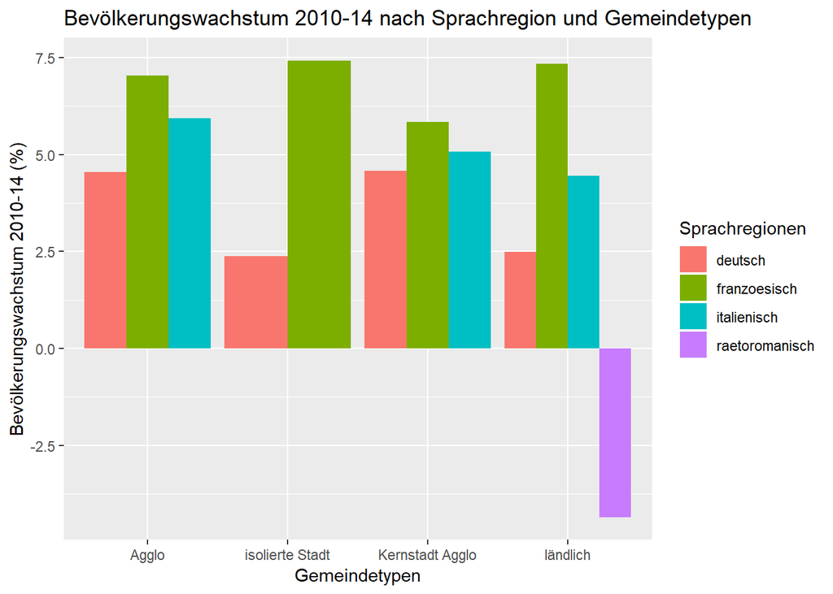

```r
p <- ggplot(gde.growth,
            aes(gde.growth$stadt_land,
                gde.growth$growth))
p +  geom_bar(stat = "identity",
              aes(fill=gde.growth$sprachregionen),
              position="dodge") +
  ggtitle("Bevölkerungswachstum 2010-14 nach Sprachregion und Gemeindetypen") +
  xlab("Gemeindetypen") +
  ylab("Bevölkerungswachstum 2010-14 (%)") +
  labs(fill = "Sprachregionen")
```

# 8. Korrelationsanalyse

- Untersuchen Sie die Zusammenhangsstruktur folgender Variablen: bev_dichte, bev_ausl, alter_0_19, alter_20_64, alter_65,bevbew_geburt,sozsich_sh, strafen_stgb.
- Gibt es Korrelationen? Falls ja, lassen Sie sich erklären oder sind sie eher unerwartet? Suchen Sie sich einen Ihnen interessant erscheinenden Zusammenhang und schauen Sie sich diesen in einem eigenen Scatterplot an

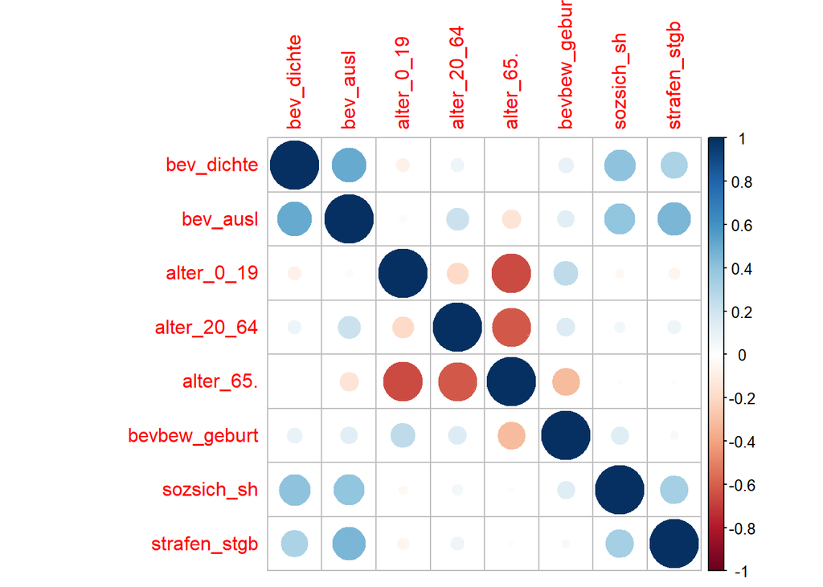

```r
cordata <- gemeindedaten.raw %>%
  dplyr::select(bev_dichte, bev_ausl, alter_0_19, alter_20_64, alter_65., bevbew_geburt,sozsich_sh, strafen_stgb )

mcor<-cor(cordata)
corrplot(mcor)
```

- Verschiedene positive Korrelationen können aus der Grafik gelesen werden:
  - bev_dichte vs bev_ausl
    - kommen eher die Einwanderung zu den städtischen Gebiete?
  - bev_ausl vs Strafen_stgb,
    - mehr Kriminalität in der Städten, warum? Parallel mit der 1. Korrelation?
  - sozsich_sh vs bev_ausl
    - mehr Ausländer beziehen soziale Hilfe ?
  - sozsich_sh vs bev_dichte
    - mehr Leute beziehen soziale Hilfe in den Städten, warum? Parallel mit Korrelation oben? oder einfach ein besseres soziales Netz in den nicht-städtischen Gebieten?
- Es kommen auch negative Korrelationen hervor:
  - alter_65 vs. alter_0_19
  - alter_65 vs. alter_20_64
    - findet ein “Exode” aus bestimmten Regionen statt ? wegen Arbeitsmöglichkeite ?
- Erstellen der Scatterplots für diese Fragestellungen bev_dichte, bev_ausl,sozsich_sh, strafen_stgb:

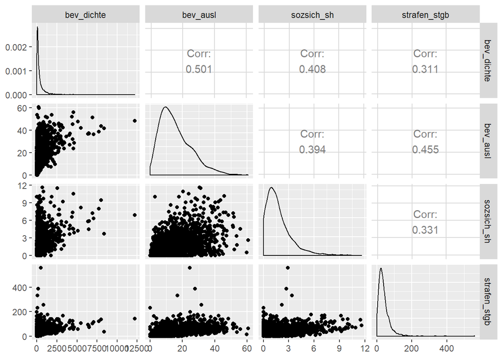

```r
cor1  <- gemeindedaten.raw %>%
  dplyr::select(bev_dichte, bev_ausl,sozsich_sh, strafen_stgb )
ggpairs(cor1, 1:4)
```

- Patterns sind erkennbar, die auf einer positiven Korrelationen hinweist.

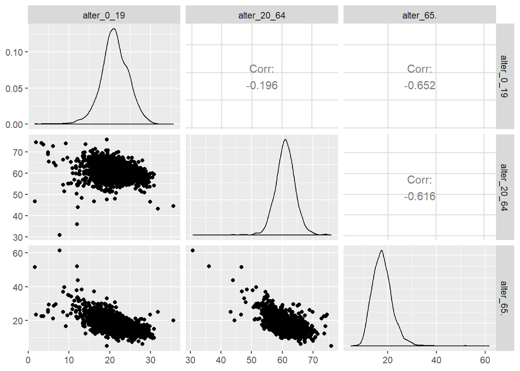

```r
cor2  <- gemeindedaten.raw %>%
  dplyr::select(alter_0_19, alter_20_64, alter_65. )

ggpairs(cor2, 1:3)
```

- klare negative Korrelationen erkennbar.

# 9. Spezifizitäten der Sprachregionen

- Visualisieren Sie eine Kontingenztabelle mit den Variablen Stadt_Land und Sprachregionen.

```r
# Welcher Gemeindetyp überwiegt bei deutschsprachigen Gemeinden, welcher bei italienischsprachigen Gemeinden. Gibt es in jeder Sprachregion isolierte Städte?
lang.typ <- gemeindedaten.raw %>%
  dplyr::select(sprachregionen, stadt_land) %>%
  group_by(sprachregionen, stadt_land) %>%
  summarise(n=n()) %>%
  arrange(sprachregionen, desc(n))

xtabs(lang.typ$n ~ lang.typ$sprachregionen + lang.typ$stadt_land, data=lang.typ)
```

```
##                        lang.typ$stadt_land
## lang.typ$sprachregionen Agglo isolierte Stadt Kernstadt Agglo ländlich
##          deutsch          510               4              42      903
##          franzoesisch     225               1              16      443
##          italienisch       83               0               5       64
##          raetoromanisch     0               0               0       28
```

# 10. Politisches Profil der Sprachregionen

- Erstellen Sie ein politisches Profil nach Sprachregionen mit der Hilfe derVariablen zu den Wähleranteilen.
- Zuerst erstelle ich eine Tabelle der Wähleranteile per Sprachregion, bezogen auf der Population:

```r
polit <- gemeindedaten.raw %>%
  dplyr::select(sprachregionen,
                bev_total,
                polit_svp,
                polit_sp,
                polit_fdp,
                polit_cvp,
                polit_gps,
                polit_evp,
                polit_glp,
                polit_bdp,
                polit_klre,
                polit_ubrige) %>%
  group_by(sprachregionen) %>%
  summarise(pop = sum(bev_total),
            svp = round(sum( polit_svp * bev_total / 100, na.rm=T) / pop,3),
            sp = round(sum(polit_sp * bev_total / 100, na.rm=T) / pop,3),
            fdp = round(sum(polit_fdp * bev_total / 100, na.rm=T) / pop,3),
            evp = round(sum(polit_evp * bev_total / 100, na.rm=T) / pop,3),
            gps = round(sum(polit_gps * bev_total / 100, na.rm=T) / pop,3),
            bdp = round(sum(polit_bdp * bev_total / 100, na.rm=T) / pop,3),
            glp = round(sum(polit_glp * bev_total / 100, na.rm=T) / pop,3),
            cvp = round(sum( polit_cvp * bev_total / 100, na.rm = T) / pop,3),
            klre = round(sum( polit_klre * bev_total / 100, na.rm = T) / pop,3),
            ubrige = round(sum( polit_ubrige * bev_total / 100, na.rm = T) / pop,3))

polit
```

```
## # A tibble: 4 x 12
##   sprachregionen    pop   svp    sp   fdp   evp   gps   bdp   glp   cvp
##   <fct>           <int> <dbl> <dbl> <dbl> <dbl> <dbl> <dbl> <dbl> <dbl>
## 1 deutsch        5.82e6 0.327 0.188 0.143 0.024 0.067 0.051 0.056 0.1
## 2 franzoesisch   2.03e6 0.207 0.221 0.223 0.014 0.096 0.012 0.026 0.122
## 3 italienisch    3.65e5 0.126 0.162 0.232 0     0.034 0.003 0.009 0.196
## 4 raetoromanisch 2.39e4 0.226 0.136 0.084 0     0     0.14  0.054 0.359
## # ... with 2 more variables: klre <dbl>, ubrige <dbl>
```

- Für die Grafische Darstellung werde ich ein separaten Barplot per Region erstellen:

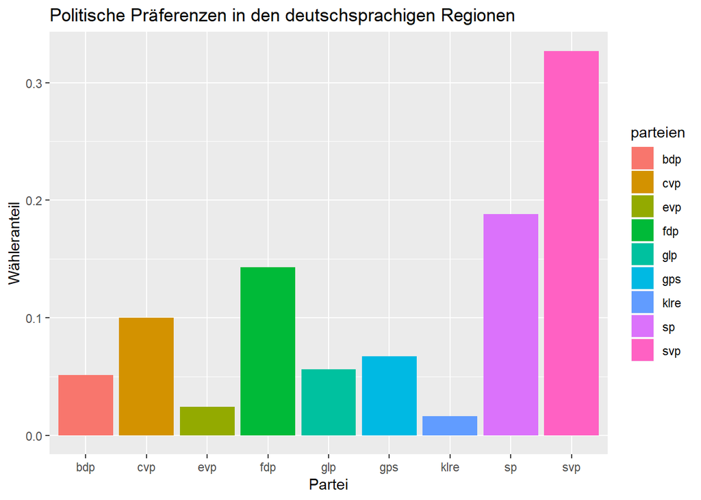

```r
d <- t(polit[1,3:11])
f <- t(polit[2,3:11])
i <- t(polit[3,3:11])
r <- t(polit[4,3:11])

parteien <- rownames(d)

pol <- data.frame(d)
pol$f <- f
pol$i <- i
pol$r <- r

pd <- ggplot(pol,aes(parteien, pol$d))
pd +  geom_bar(stat = "identity",
              aes(fill=parteien),
              position="dodge") +
  ggtitle("Politische Präferenzen in den deutschsprachigen Regionen") +
  xlab("Partei") +
  ylab("Wähleranteil")
```

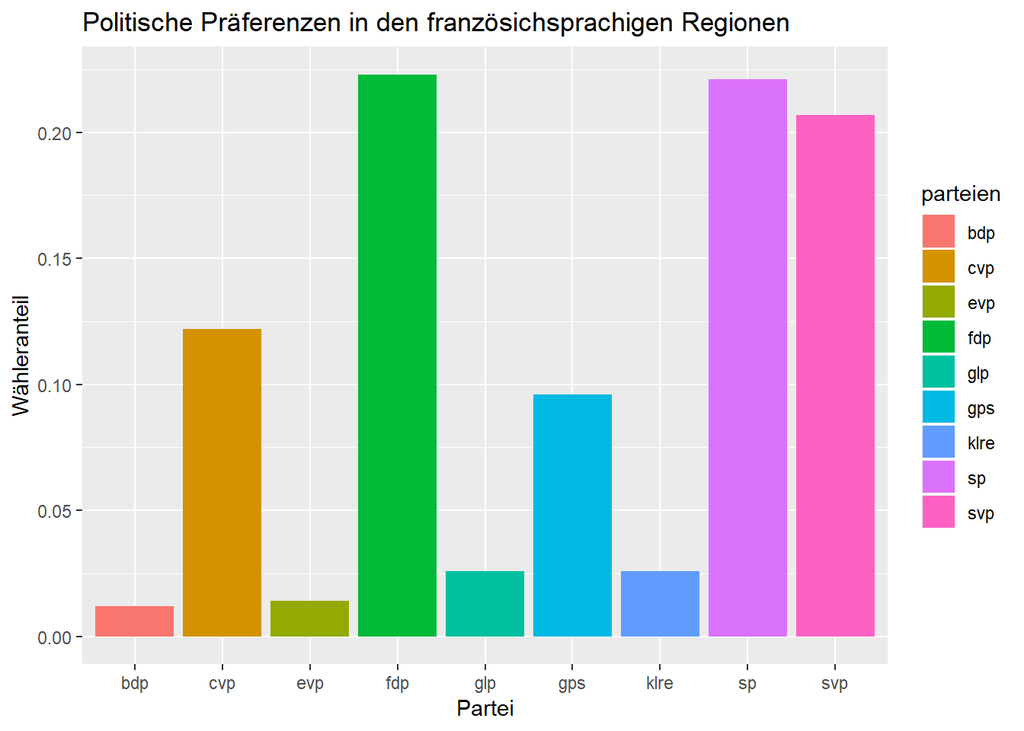

```r
pf <- ggplot(pol,aes(parteien, pol$f))
pf +  geom_bar(stat = "identity",
              aes(fill=parteien),
              position="dodge") +
  ggtitle("Politische Präferenzen in den französichsprachigen Regionen") +
  xlab("Partei") +
  ylab("Wähleranteil")
```

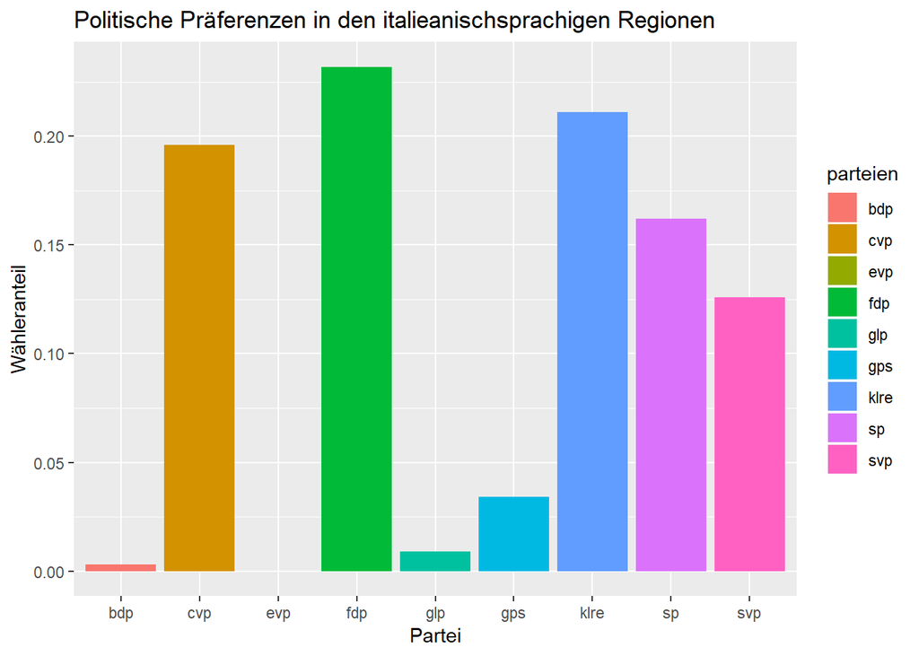

```r
pi <- ggplot(pol,aes(parteien, pol$i))
pi +  geom_bar(stat = "identity",
              aes(fill=parteien),
              position="dodge") +
  ggtitle("Politische Präferenzen in den italieanischsprachigen Regionen") +
  xlab("Partei") +
  ylab("Wähleranteil")
```

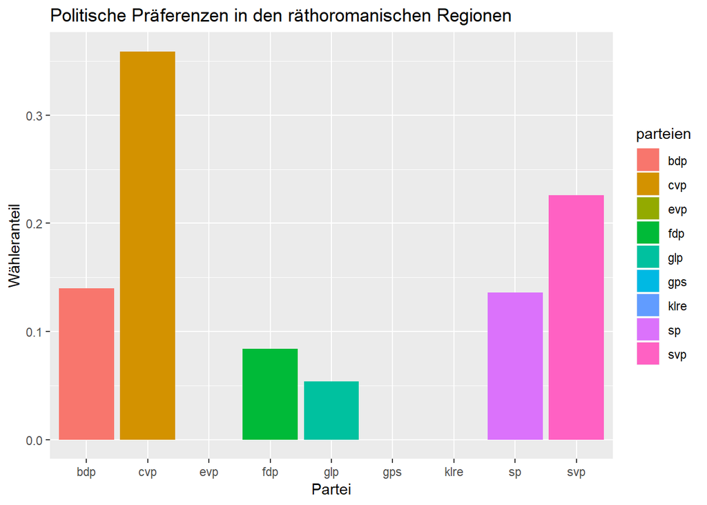

```r
pr <- ggplot(pol,aes(parteien, pol$r))
pr +  geom_bar(stat = "identity",
              aes(fill=parteien),
              position="dodge") +
  ggtitle("Politische Präferenzen in den räthoromanischen Regionen") +
  xlab("Partei") +
  ylab("Wähleranteil")
```

- Merkpünkte :
  - sp stärker in den französichsprachigen Gebiete als in den deutschsprachigen Gebiete.
  - svp stärker in den deutschsprachigen Gebiete als in der französichsprachigen und italieanischsprachigen Gebiete. In italieanischsprachigen Gebiete spielt der Anteil der Lega (“kleine Rechtsparteien”) eine Rolle.
  - fdp bedeutender in den französichsprachigen und italieanischsprachigen Gebiete als in der Deutschschweiz.
  - gps markant stärker im französichsprachigen Raum.